# Re-analysis of Caviola et al. (2020)

This is the analysis underlying the post [The 100x multiplier on effective charities](https://docs.google.com/document/d/1KmfrVB5ZkFBgss1047nhes5R-bwLDFe8Qx5NnLwU8XE/edit?usp=sharing) which is a re-analysis of the data from the [Caviola et al. (2020)](http://journal.sjdm.org/20/200504/jdm200504.pdf) experiment. The authors generously posted the data and analysis scripts [here](https://osf.io/k4zfr/).

The paper itself is purely descriptive and relies mostly on medians. In this re-analysis, we are particularly interested in study 4, wherein experts in charity effectiveness evaluate how much more good the world’s most effective charities do compared to an average charity.

## Expert judgments

Let’s load the data directly from OSF:

```r
library(dplyr, warn.conflicts = FALSE)

df_experts = read.csv("https://osf.io/mshfq/download") |>
  filter(Finished == 1) |>
  select(ratio, expert)
```

Looking at the expert’s ratings, it’s clear that there are a few extreme values:

```r
sort(df_experts$ratio)
```

```
##  [1]      0.25      1.96      2.00      3.00      4.00      6.00     10.00
##  [8]     10.00     10.00     10.00     12.00     12.00     14.00     20.00
## [15]     20.00     20.00     25.00     25.00     30.00     50.00     50.00
## [22]    100.00    100.00    100.00    100.00    100.00    100.00    100.00
## [29]    100.00    100.00    125.00    150.00    177.00    200.00    200.00
## [36]    500.00   1000.00   1000.00   1000.00   1000.00   1000.00   1000.00
## [43]   9999.00  10000.00  10000.00 450000.00
```

Caviola et al. primarily interpreted the median of the full sample, which is a 100x multiplier given the many responses at 100:

```r
median(df_experts$ratio)
```

```
## [1] 100
```

We filter out the extreme estimation of 450,000x effectiveness and the erroneous one at 0.25. As it turns out, the data is ok approximated as a log-normal distribution:

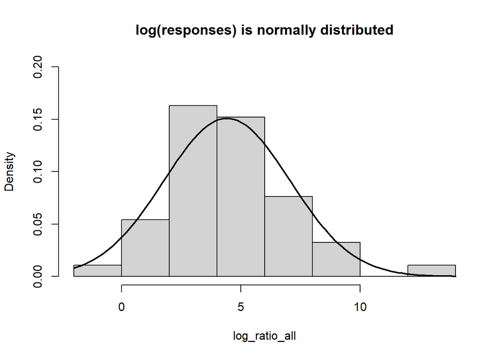

```r
log_ratio_all = log(df_experts$ratio)
hist(log_ratio_all, breaks = 7, freq = FALSE, main = "log(responses) is normally distributed", ylim = c(0, 0.2))
curve(dnorm(x, mean = mean(log_ratio_all), sd = sd(log_ratio_all)), add = TRUE, lwd = 2)
```

This is not surprising given that this is ratio data.

Side note: If you run this using `breaks = 20`, it’s clear that the reference-number effect (also called [Terminal Digit Preference](https://en.wikipedia.org/wiki/Terminal_digit_preference)) plays a major role (the tendency to choose 10, 50, 100, 1,000, etc.). But since this is probably more a feature of the experts’ uncertainty than a true feature of the distribution of their underlying evaluation of the multiplier, we continue with the log-normal assumption. Actually, the 450,000x multiplier is not too unlikely under this distribution, but we leave it out anyway.

We can now compute the mean of this distribution, which is $\exp\left(\mu+\frac{\sigma^2}{2}\right)$ (see [Wikipedia](https://en.wikipedia.org/wiki/Log-normal_distribution)). First using all data, we get this multiplier:

```r
log_mean = function(x) exp(mean(x) + sd(x)^2/2)
log_ratio = log(df_experts$ratio[df_experts$ratio >= 1 & df_experts$ratio <= 10000])
log_mean(log_ratio)
```

```
## [1] 852.4867
```

```r
log_ratio_topexperts = log(df_experts$ratio[df_experts$expert >= 4 & df_experts$ratio >= 1 & df_experts$ratio <= 10000])
log_mean(log_ratio_topexperts)
```

```
## [1] 680.3702
```

```r
log_ratio_conservative = log(df_experts$ratio[df_experts$expert >= 4 & df_experts$ratio >= 1 & df_experts$ratio <= 1000])
log_mean(log_ratio_conservative)
```

```
## [1] 319.3231
```

## Expert judgments: extra analyses

```r
df_experts |>
  filter(ratio >= 1, ratio <= 10000) %>%
  group_by(is_top_expert = expert %in% c(4, 5)) %>%
  summarise(
    N_participants = n(),
    median = median(ratio),
    mean = log_mean(log(ratio))
  )
```

```
## # A tibble: 2 x 4
##   is_top_expert N_participants median  mean
##   <lgl>                  <int>  <dbl> <dbl>
## 1 FALSE                     26   22.5  881.
## 2 TRUE                      18  100    680.
```

## Lay people’s judgments

Let’s get the data from OSF. There’s a treasure trove of data in these tables, but for now let’s focus on the ratio as judged via the tipping point since that’s the only one available in both:

```r
# MTurk: lay people
df_mturk = read.csv("https://osf.io/6tdmf/download", sep = ";") |>
  #select(ratio = ExplicitComparison) |>
  mutate(
    ratio = Tipping_point / 1000,
    sample = "mturk"
  )

# Oxford students
df_oxford = read.csv("https://osf.io/vmrus/download") |>
  filter(is.na(EG) == FALSE) |>
  mutate(
    ratio = EG / 1000,
    sample = "oxford students"
  )

# Bind them together
df_both = bind_rows(
  df_mturk |> select(ratio, sample),
  df_oxford |> select(ratio, sample)
)
```

Here is their judgment:

```r
# remove misunderstandings (<1) and one extreme response
log_lay = log(df_both$ratio[df_both$ratio <= 5000 & df_both$ratio >= 1])

log_mean(log_lay)
```

```
## [1] 2.998235
```

And a visual presentation of how many participants reported below a particular number:

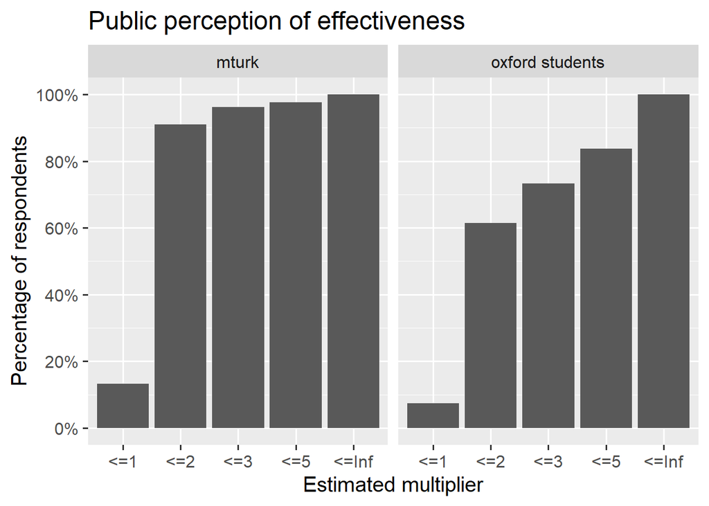

```r
library(ggplot2)
df_both |>
  # Compute the proportion of responss below each of these thresholds per group
  tidyr::expand_grid(cutoff = c(1, 2, 3, 5, Inf)) |>
  group_by(sample, cutoff) |>
  summarise(
    proportion = sum(ratio <= cutoff) / n(),
    cutoff = paste0("<=", first(cutoff)),
    .groups = "drop"
  ) |>

  # Plot it
  ggplot(aes(x = cutoff, y = proportion)) +
  geom_col() +
  facet_wrap(~sample) +
  scale_y_continuous(labels = scales::percent_format(), breaks = seq(0, 1, 0.2)) +
  labs(x = "Estimated multiplier", y = "Percentage of respondents", title = "Public perception of effectiveness") +
  theme_gray(15)
```

MTurk respondents also answered how much it would cost for the effective and average charities to save a life. Half of the respondents thought that it would be very cheap (<$100 per life) while only 8.6% believed that saving a life was more expensive than the current GiveWell estimate ($3800).

```r
df_long = df_mturk |>
  tidyr::pivot_longer(c(High_cost_effec, Low_cost_effec)) |>
  filter(is.na(value) == FALSE)

# 50% estimate below this value
median(df_long$value)
```

```
## [1] 100
```

```r
1 - sum(df_long$value < 3800, na.rm = TRUE) / nrow(df_long)
```

```
## [1] 0.08591885
```

Let’s visualize this:

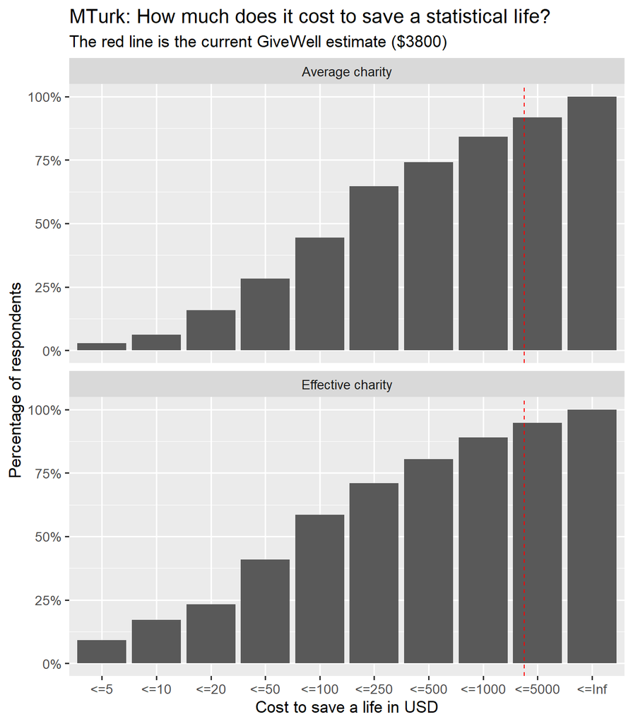

```r
df_cost = df_long |>
  tidyr::expand_grid(cutoff = c(5, 10, 20, 50, 100, 250, 500, 1000, 5000, Inf)) |>
  filter(is.na(value) == FALSE) |>
  group_by(name, cutoff) |>
  summarise(
    prop = sum(value <= cutoff) / n(),
    .groups = "drop"
  ) |>
  ungroup() |>
  mutate(
    cutoff = as.factor(cutoff),
    cutoff = paste0("<=", cutoff) |> forcats::fct_inorder(),
    name = case_when(
      name == "High_cost_effec" ~ "Effective charity",
      TRUE ~ "Average charity"
    )
  )

ggplot(df_cost, aes(x = cutoff, y = prop)) +
  geom_col() +
  geom_vline(xintercept = 8.76, lty = 2, col = "red") +  # Hack to show around $3800
  facet_wrap(~name, ncol = 1) +
  scale_y_continuous(labels = scales::percent_format()) +
  labs(x = "Cost to save a life in USD", y = "Percentage of respondents", title = "MTurk: How much does it cost to save a statistical life?", subtitle = "The red line is the current GiveWell estimate ($3800)") +
  theme_grey(13)
```